# Using the FDR controlling test procedure of Bodnar, Dickhaus (2014)

Jonathan von Schroeder

2019-01-21

This vignette demonstrates the usage of the FDR controlling procedure of T. Bodnar and T. Dickhaus (2014). The paper is available at https://projecteuclid.org/euclid.ejs/1414588192. All following references to equations and theorems refer to this paper.

## Performing FDR controlling tests using `ac_fdr.test`

Consider, for example, p-values $P_i$ given by
$$\begin{aligned}
P_i&=\begin{cases}
U_i&\text{for }i=1,\cdots,m_0\\
\Phi\left(\mu_i+\Phi^{-1}(U_i)\right)&\text{for }i=m_0+1,\cdots,m
\end{cases}
\end{aligned}$$
where $U=(U_1,\cdots,U_m)^T$ is a vector of marginally uniformly distributed random variables following a Clayton copula with parameter $\eta=1$. These can be generated as follows:

```r
library(copula)
set.seed(1)
m <- 20
m0 <- 0.8*m
p_values <- rCopula(1,onacopulaL(copClayton,list(1,1:20)))
mu<-runif(m-m0, min=-1, max=-1/2)
p_values[1,(m0+1):m]<-pnorm(sqrt(m)*mu+qnorm(p_values[(m0+1):m]),0,1)
```

The FDR controlled simultaneous test of the hypotheses $H_i:\mu_i=0$ versus the alternatives $K_i:\mu_i<0$ can then be performed in terms of these p-values:

```r
ac_fdr.test(p_values,setTheta(copClayton,1),m0,0.05,1e4)$test
```

```
#>  [1] FALSE FALSE FALSE FALSE FALSE FALSE FALSE FALSE FALSE FALSE FALSE
#> [12] FALSE FALSE FALSE FALSE FALSE  TRUE  TRUE  TRUE  TRUE
```

For a discussion of the methods than can be utilised for empirical copula calibration (i.e. estimating the copula parameter from observations) see section 5 of T. Bodnar and T. Dickhaus (2014).

## Generating Figures 1 and 5

The distribution function at $z$ can be evaluated by

```r
cdf.Z(copula::setTheta(cop,theta),z)
```

where `cop` is a copula object (i.e. `copula::copClayton`). Thus for the simulation it is only necessary to specify the calculation of $z^*$. For the Clayton copula this is given by

```r
z_star_Clayton <- function(m,q,eta) {
  log(m) / ((m/q)^eta - (1/q)^eta)
}
```

Note that, to be compatible with the [copula-package](https://CRAN.R-project.org/package=copula), this example uses a generator that differs from the one used in the paper (cf. page 2218). The generator used for the Clayton copula is given by $\psi(x)=(1+x)^{-1/\eta}$ which leads to qualitatively similar results to those obtained in the paper.

For the Gumbel copula $z^*$ can be calculated by

```r
z_star_Gumbel <- function(m,q,eta) {
  log(m) / ((-log(q/m))^eta-(-log(q))^eta)
}
```

Note: Since `z_star_Gumbel` is very small for larger `theta` (for example `z_star_Gumbel(200,0.05,15)` is of the same magnitude as $10^{-14}$) a Monte Carlo approximation to the distribution function is utilized for larger theta. In the paper this was done for all `theta`.

To see the full code for generating the figures execute the following code:

```r
v <- vignette('fdr-test',package = 'MHTcop')
file.edit(paste(v$Dir,'doc',v$R,sep='/'))
```

### Figure 1 (for the Clayton copula)

#### Figure 1 a)

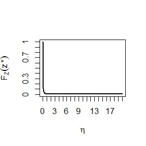

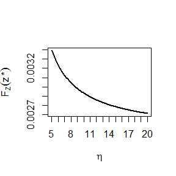

#### Figure 1 b)

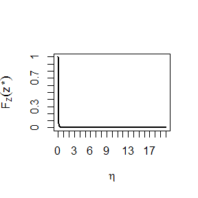

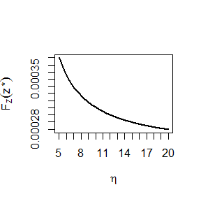

## Figure 5 (for the Gumbel copula)

#### Figure 5 a)

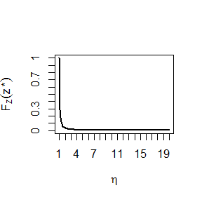

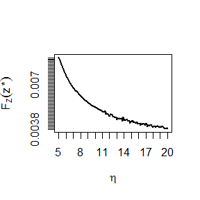

#### Figure 5 b)

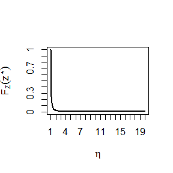

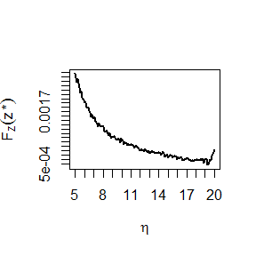

## Performing the simulations for Figures 2a), 3a), 4a) and Figures 6a), 7a), 8a)

### Calculating the upper bound for the FDR according to corollary 3.1

The upper bound is calculated according to the formula given in corollary 3.1. The adjustement factor $\delta$ is calculated using the function `ac_fdr.calc_delta`:

```r
calcBounds <- function(cop) {
  upperBound <- (m0/m)*alpha
  cat("Calculating upper bound for the",cop@name,"copula ( m =",m,")\n")
  delta <- pbsapply(theta,function(theta)
   ac_fdr.calc_delta(copula::setTheta(cop,theta),m,m0,
   alpha=alpha,num.reps=NZ,calc.var=TRUE))
  sharperUpperBound <- upperBound * delta[1,]
  sharperUpperBound.var <- upperBound^2 * delta[2,]
  delta <- delta[1,]
  lowerBound <- sapply(theta,function(theta){alpha*(m0/m)*
   (1+pgamma(log(m)/(m^(theta)-1),shape=1/(theta),scale=1)-
      pgamma((log(m)*(m^(theta)))/(m^(theta)-1),shape=1/(theta),scale=1))})
  list(upperBound=upperBound,sharperUpperBound=sharperUpperBound,
       sharperUpperBound.var=sharperUpperBound.var,
       delta=delta,lowerBound=lowerBound)
}
```

### Simulation study to determine the FDR under model (16)

Samples from model (16) for use in a Monte Carlo study of the FDR using the delta calculated previously by `calc_bounds`:

```r
simFDR <- function(cop,delta) {
  cat("Performing simulation for the",cop@name,"copula ( m =",m,")\n")
  Sim <- do.call(cbind,pblapply(seq_along(theta),function(l) {
    p_values<-matrix(0,3,m)
    q_k<-(alpha/m)*seq(1,m,1)
    p_values_data <- copula::rCopula(NZ,copula::onacopulaL(cop,list(theta[l],1:m)))
    data_f<-function(s)
    {
      p_values[1,]<-p_values_data[s,]
      p_values[2,1:m]<-0
      mu<-runif(m-m0, min=-1, max=-1/2)
      p_values[1,(m0+1):m]<-pnorm(sqrt(m)*mu+qnorm(p_values_data[s,(m0+1):m]),0,1)
      p_values[2,(m0+1):m]<-1
      sp_values<-matrix(0,3,m)
      sp_values<-p_values[,order(p_values[1,])]
      sp_values[3,]<-seq(1,m,1)

      #Calculations for the FDR
      R_m<-0
      V_m<-0
      if (sum(sp_values[1,]<q_k)>0)
      {
        R_m<-sum(max(sp_values[3,sp_values[1,]<q_k]))
        V_m<-R_m-sum(sp_values[2,1:R_m])
      }

      #Calculations for the power
      S_m<-0
      if (sum(sp_values[1,]<q_k)>0)
      {
        S_m<-sum(sp_values[2,1:sum(max(sp_values[3,sp_values[1,]<q_k]))])
      }

      #Calculations for the power of the improved procedure
      S_m.improved<-0
      if (sum(sp_values[1,]<q_k/delta[l])>0)
      {
        S_m.improved<-sum(sp_values[2,1:sum(max(sp_values[3,sp_values[1,]<q_k/delta[l]]))])
      }

      return(c(V_m/max(1,R_m),S_m/(m-m0),S_m.improved/(m-m0)))
    }
    data_in<-sapply(1:NZ,data_f)
    FDR.sd <- sd(data_in[1,])
    data_in<-rowMeans(data_in)
    data_in[4]<-FDR.sd
    return(data_in)
  }))
  list(FDR=Sim[1,],empiricalPower=Sim[2,],empiricalPowerImproved=Sim[3,],
       FDR.sd=Sim[4,])
}
```

### The results

```
#> Generating Figure 2 a )
```

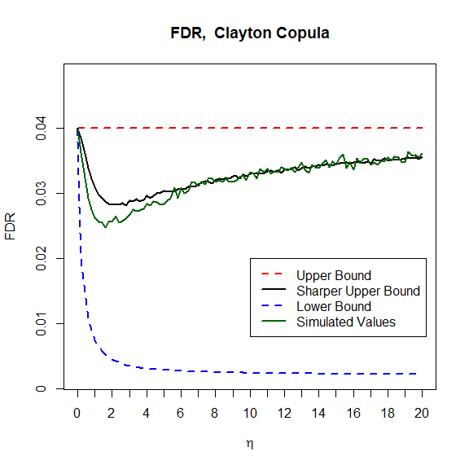

```
#> Generating Figure 3 a )
```

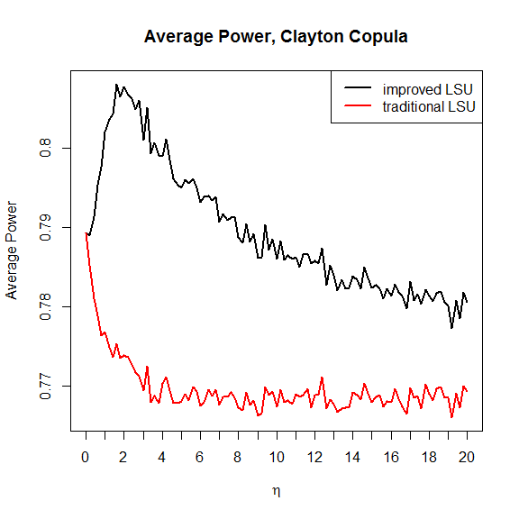

```
#> Generating Figure 4 a )
```

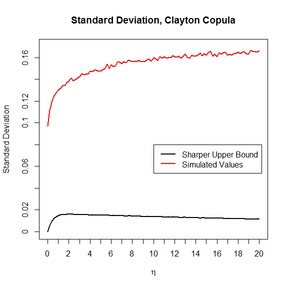

```
#> Generating Figure 6 a )
```

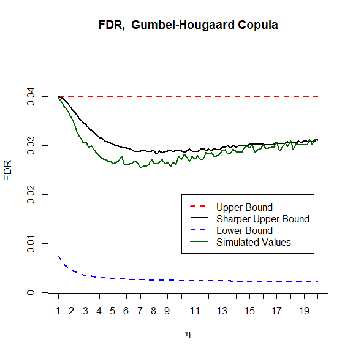

```
#> Generating Figure 7 a )
```

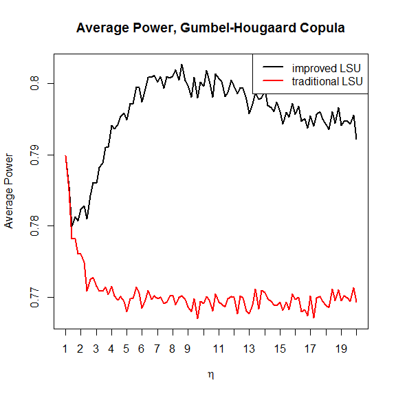

```
#> Generating Figure 8 a )
```

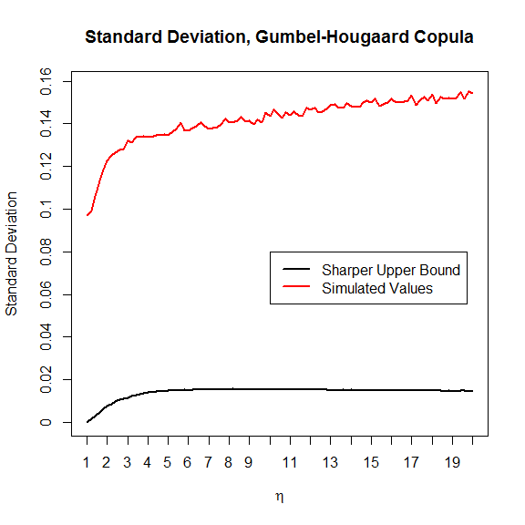